# От вектора к текстам в R

Konstantin Ivanin

26 сентября 2017 г

# Частотность

Загрузим библиотеки

```r
library(tidyverse)
library(magrittr)
library(tidytext)
library(stringr)
```

Подготовка

```r
temp <- tempfile() # создаем временный файл
path <- 'data/Chekhov/'
download.file('https://goo.gl/9DWBF5', destfile = temp) # скачиваем в него архив
unzip(temp, exdir = path) # создаем папку Chekhov и распаковываем туда
rm(temp) # удаляем временный файл
list.files(path = path) # смотрим на список распокованных файлов
```

```
##  [1] "cinik.txt"
##  [2] "dachniki.txt"
##  [3] "delec.txt"
##  [4] "dorogaya_sobaka.txt"
##  [5] "gost.txt"
##  [6] "intellegentnoje_delo.txt"
##  [7] "jeger.txt"
##  [8] "mertvoje_telo.txt"
##  [9] "mislitel.txt"
## [10] "moi_jeni.txt"
## [11] "nalim.txt"
## [12] "ne_sudba.txt"
## [13] "nervi.txt"
## [14] "ninochka.txt"
## [15] "obshee_obrazovaniye.txt"
## [16] "otec_semejstva.txt"
## [17] "psichopaty.txt"
## [18] "rukovodstvo_dlya_zhelayushich_zhenica.txt"
## [19] "rybje_delo.txt"
## [20] "sapogi.txt"
## [21] "simulianti.txt"
## [22] "starosta.txt"
## [23] "stena.txt"
## [24] "straji_pod_strajey.txt"
## [25] "svistuni.txt"
## [26] "utoplennik.txt"
## [27] "v_apteke.txt"
## [28] "zabludshije.txt"
## [29] "zhenich_i_papenka.txt"
## [30] "zloumishlennik.txt"
```

```r
files <- list.files(path = path) # создадим переменную со списком файлов
texts <- lapply(paste0(path, files), FUN = readLines) # считаем все файлы в одну переменную
```

## Еще немножко о законе Ципфа

У функции `unnest_tokens()` есть аргумент `token`, значение которого по умолчанию `'words'`. Попробуйте использовать значение `'characters'` и определить будет ли соблюдаться закон Ципфа для отдельных символов.

Введение в `tidytext`. Тайдифицируем рассказы Чехова:

```r
texts <- lapply(seq_along(texts), function(x) {
  data_frame(title = files[[x]],
  sentences = seq_along(texts[[x]]),
  text = texts[[x]])
})

all_texts <- Reduce(function(x, y) {merge(x, y, all = TRUE)}, texts)
# http://adv-r.had.co.nz/Functionals.html - почитать про Reduce

all_texts %>%
  unnest_tokens(char, text, token = 'characters') -> tidy_chekhov
head(tidy_chekhov)
```

```
##         title sentences char
## 1   cinik.txt         1    п
## 1.1 cinik.txt         1    о
## 1.2 cinik.txt         1    л
## 1.3 cinik.txt         1    д
## 1.4 cinik.txt         1    е
## 1.5 cinik.txt         1    н
```

Построим график:

```r
tidy_chekhov %>%
  group_by(char) %>%
  summarise(term_frequency = n() / nrow(tidy_chekhov)) %>%
  arrange(desc(term_frequency)) %>%
  mutate(rank = row_number()) -> zipf
head(zipf)
```

```
## # A tibble: 6 x 3
##    char term_frequency  rank
##   <chr>          <dbl> <int>
## 1     о     0.10262128     1
## 2     е     0.08585626     2
## 3     а     0.08355798     3
## 4     и     0.06841419     4
## 5     т     0.06699795     5
## 6     н     0.06038884     6
```

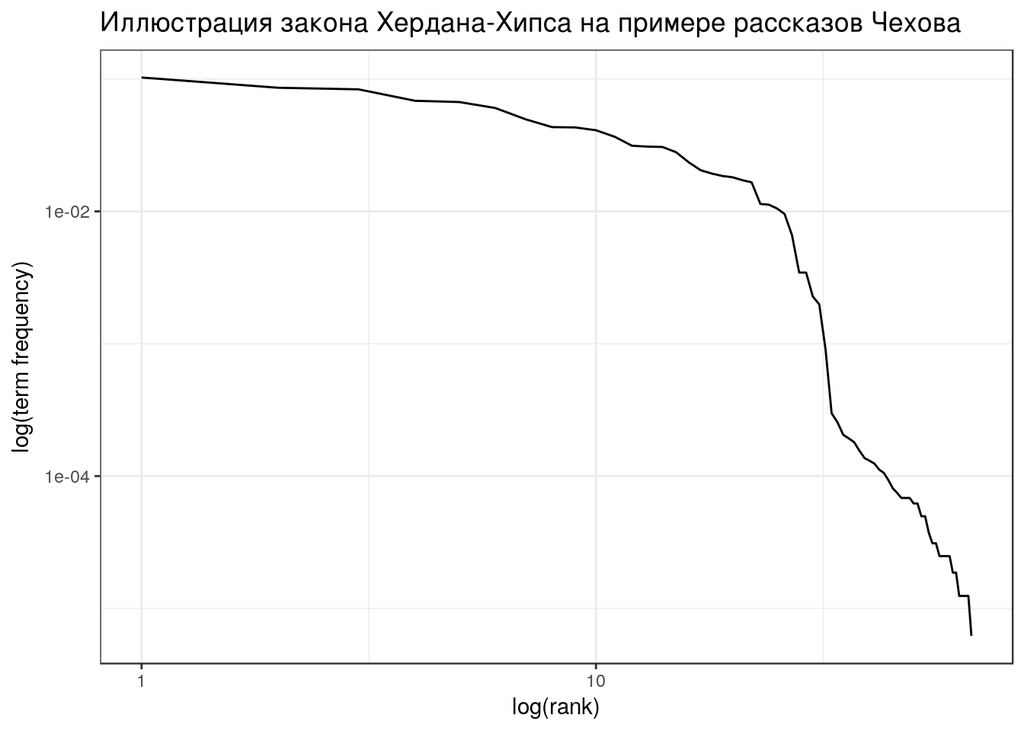

```r
zipf %>%
  ggplot(aes(rank, term_frequency)) +
  geom_line() +
  scale_x_log10() +
  scale_y_log10() +
  labs(title = 'Иллюстрация закона Хердана-Хипса на примере рассказов Чехова',
  y = 'log(term frequency)',
  x = 'log(rank)') +
  theme_bw()
```

## Фамильная честь Вустеров

Возможно, это прозвучит скучно, но давайте повторим все, что мы прошли, используя роман П. Г. Вудхауза “Фамильная честь Вустеров”.

- скачайте [текст романа](https://goo.gl/rgatpY)
- создайте переменную, отвечающую за номер главы (название давайте включим в первую главу).
- tidyфицируйте текст (занудства ради я бы попросил создать переменную с номером строки: `row_number()`)
- В какой главе живет самая частотная униграмма?
- Уберите стоп-слова. В какой главе теперь живет самая частотная униграмма?
- Посчитайте TfIdf (исключив стоп-слова). В какой главе живет слово с самым высоким значением TfIdf?
- Посчитайте TfIdf (исключив стоп-слова) для биграмного представления текста.
- Постройте график зависимости абсолютной частоты и меры TfIdf. Назовите, какие четыре биграммы выглядят выбросами на графике.
- Напишите функцию `text_generater()`, которая будет генерировать текст заданной наперед длины на основе частотной биграммной модели, построенной на основе входного текста.

Подготовка

```r
text <- readLines('data/3.9.2 Wodehouse.txt')
text %<>% paste(collapse = ' ') %>%
  str_split('ГЛАВА \\d+', simplify = T)
text <- text[1, ]
text[2] <- paste(text[1], text[2])
text <- text[2:15]

df <- tibble(chapter = paste('Глава', seq_along(text), sep = '_'), text = text[seq_along(text)])
df %<>%
  mutate(text = str_replace_all(text, '\\s+', ' '))

sw <- read_csv('https://goo.gl/pfpUrB', col_names = FALSE)$X1
```

tidyфицируем текст

```r
tidy.text <- df %>%
  unnest_tokens(text, text)
```

Самая частотная униграмма

```r
tidy.text %>%
  count(chapter, text, sort = T) %>%
  head(1)
```

```
## # A tibble: 1 x 3
##   chapter  text     n
##     <chr> <chr> <int>
## 1 Глава_4     и   233
```

Самая частотная униграмма без стоп слов

```r
tidy.text %>%
  filter(!text %in% sw) %>%
  count(chapter, text, sort = T) %>%
  head(1)
```

```
## # A tibble: 1 x 3
##    chapter  text     n
##      <chr> <chr> <int>
## 1 Глава_14   сэр    77
```

tfidf для униграмм

```r
tfidf.text <- tidy.text %>%
  filter(!text %in% sw) %>%
  count(chapter, text) %>%
  arrange(desc(n)) %>%
  bind_tf_idf(chapter, text, n)

tfidf.text %>%
  filter(tf_idf == max(tf_idf))
```

```
## # A tibble: 258 x 6
##    chapter       text     n    tf      idf   tf_idf
##      <chr>      <chr> <int> <dbl>    <dbl>    <dbl>
##  1 Глава_6  связывать     4     1 2.855068 2.855068
##  2 Глава_6       дашь     2     1 2.855068 2.855068
##  3 Глава_6     зелени     2     1 2.855068 2.855068
##  4 Глава_6 извиниться     2     1 2.855068 2.855068
##  5 Глава_6      палец     2     1 2.855068 2.855068
##  6 Глава_6     подали     2     1 2.855068 2.855068
##  7 Глава_6    простит     2     1 2.855068 2.855068
##  8 Глава_6   свернете     2     1 2.855068 2.855068
##  9 Глава_6     сверну     2     1 2.855068 2.855068
## 10 Глава_6     сидели     2     1 2.855068 2.855068
## # ... with 248 more rows
```

tfidf для биграмм

```r
tidy.bigram <- df %>%
  unnest_tokens(bigram, text, token = 'ngrams', n = 2) %>%
  separate(bigram, c('word1', 'word2'), sep = ' ') %>%
  filter(!word1 %in% sw) %>%
  filter(!word2 %in% sw) %>%
  count(chapter, word1, word2, sort = TRUE) %>%
  unite(bigram, word1, word2, sep = ' ')

tfidf.bigram <- tidy.bigram %>%
  bind_tf_idf(bigram, chapter, n) %>%
  arrange(desc(tf_idf))

tfidf.bigram %>%
  filter(tf_idf == max(tf_idf))
```

```
## # A tibble: 1 x 6
##   chapter             bigram     n          tf      idf     tf_idf
##     <chr>              <chr> <int>       <dbl>    <dbl>      <dbl>
## 1 Глава_6 связывать простыни     3 0.006772009 2.639057 0.01787172
```

График ависимости абсолютной частоты и меры TfIdf

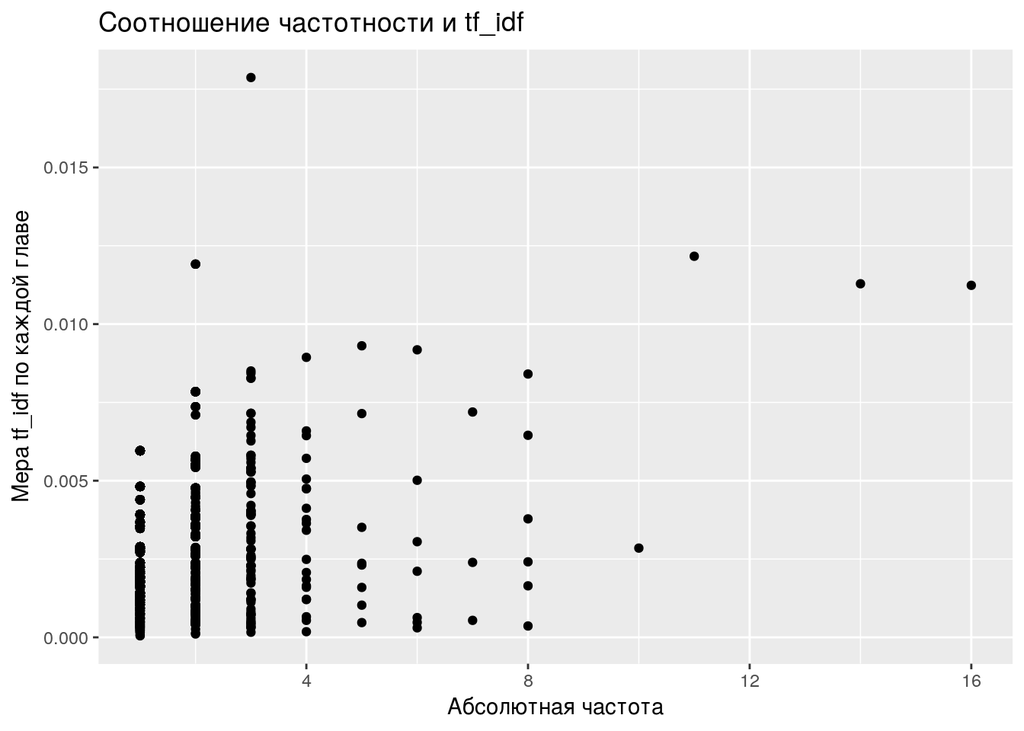

```r
tfidf.bigram %>%
  ggplot(aes(n, tf_idf)) +
  geom_point() +
  ggtitle('Соотношение частотности и tf_idf') +
  xlab('Абсолютная частота') +
  ylab('Мера tf_idf по каждой главе')
```

```r
tfidf.bigram %>%
  arrange(-n) %>%
  head(4)
```

```
## # A tibble: 4 x 6
##    chapter        bigram     n          tf       idf      tf_idf
##      <chr>         <chr> <int>       <dbl>     <dbl>       <dbl>
## 1 Глава_14 мистер вустер    16 0.010914052 1.0296194 0.011237320
## 2 Глава_12    тетя далия    14 0.025547445 0.4418328 0.011287698
## 3  Глава_9 мистер вустер    11 0.011815252 1.0296194 0.012165213
## 4  Глава_2  тотли тауэрс    10 0.008467401 0.3364722 0.002849045
```

Функция `text_generater()`

```r
text_generater <- function(first_word, text, text_length = 10, remove_sw = TRUE) {
  if (remove_sw == TRUE) {
    sw <- read_csv('https://goo.gl/pfpUrB', col_names = FALSE)$X1
  }

  df <- tibble(text = text)

  if (remove_sw == TRUE) {
      tidy.text <- df %>%
        unnest_tokens(bigram, text, token = 'ngrams', n = 2) %>%
        separate(bigram, c('word1', 'word2'), sep = ' ') %>%
        filter(!word1 %in% sw) %>%
        filter(!word2 %in% sw) %>%
        filter(!grepl(pattern = '\\d+', word1)) %>%
        filter(!grepl(pattern = '\\d+', word2)) %>%
        count(word1, word2, sort = TRUE) %>%
        unite(bigram, word1, word2, sep = ' ', remove = FALSE)
  } else {
      tidy.text <- df %>%
        unnest_tokens(bigram, text, token = 'ngrams', n = 2) %>%
        separate(bigram, c('word1', 'word2'), sep = ' ') %>%
        filter(!grepl(pattern = '\\d+', word1)) %>%
        filter(!grepl(pattern = '\\d+', word2)) %>%
        count(word1, word2, sort = TRUE) %>%
        unite(bigram, word1, word2, sep = ' ', remove = FALSE)
  }

  sub_funct <- function(word) {
    tidy.text %>%
      filter(word1 == word) %>%
      select(bigram, word2) %>%
      head(1)
  }

  res <- c()
  next.word <- first_word

  for (i in 1:(text_length - 1)) {
    sf <- sub_funct(next.word)
    if (i == 1) {
      res <- c(res, sf$bigram)
    } else {
      res <- c(res, sf$word2)
    }
    next.word <- sf$word2
  }

  return(paste(res, collapse = ' '))
  #return(tidy.text)
}

text <- readLines('data/3.9.2 Wodehouse.txt')
text_generater(first_word = 'честь', text = text, text_length = 10)
```

```
## [1] "честь вустеров величайшему испытанию какое впечатление произвел желанного действия всестороннему"
```

```r
text <- read_lines('data/book1_.txt')
text <- c(text, read_lines('data/book2_.txt'))
text_generater(first_word = 'князь', text = text, text_length = 20, remove_sw = T)
```

```
## [1] "князь андрей вышел вперед видимо желая выразить словами марья дмитриевна какое прекрасное царствование императора александра i приказывает арестовать сержанта"
```